# Titanic Temalabor

#Olvassuk be az adatokat:

```r
train <- read.csv('train.csv')
test <- read.csv('test.csv')
result <- read.csv('gender_submission.csv')
```

#a notebookban használt library-k:

```r
library(ROCR)
library(Metrics)
library(randomForest)
```

#Elemezzuk a típusaikat és értékeiket:

```r
str(train)
```

```
'data.frame':   891 obs. of  12 variables:
 $ PassengerId: int  1 2 3 4 5 6 7 8 9 10 ...
 $ Survived   : int  0 1 1 1 0 0 0 0 1 1 ...
 $ Pclass     : int  3 1 3 1 3 3 1 3 3 2 ...
 $ Name       : chr  "Braund, Mr. Owen Harris" "Cumings, Mrs. John Bradley (Florence Briggs Thayer)" "Heikkinen, Miss. Laina" "Futrelle, Mrs. Jacques Heath (Lily May Peel)" ...
 $ Sex        : chr  "male" "female" "female" "female" ...
 $ Age        : num  22 38 26 35 35 NA 54 2 27 14 ...
 $ SibSp      : int  1 1 0 1 0 0 0 3 0 1 ...
 $ Parch      : int  0 0 0 0 0 0 0 1 2 0 ...
 $ Ticket     : chr  "A/5 21171" "PC 17599" "STON/O2. 3101282" "113803" ...
 $ Fare       : num  7.25 71.28 7.92 53.1 8.05 ...
 $ Cabin      : chr  "" "C85" "" "C123" ...
 $ Embarked   : chr  "S" "C" "S" "S" ...
```

```r
sapply(train, function(y) sum(length(which(is.na(y)))))
```

```
PassengerId    Survived      Pclass        Name         Sex         Age       SibSp       Parch      Ticket        Fare
          0           0           0           0           0         177           0           0           0           0
      Cabin    Embarked
          0           0
```

```r
sapply(train, function(y) sum(length(which(y == ""))))
```

```
PassengerId    Survived      Pclass        Name         Sex         Age       SibSp       Parch      Ticket        Fare
          0           0           0           0           0           0           0           0           0           0
      Cabin    Embarked
        687           2
```

```r
train <- na.omit(train)
train$Cabin <- NULL
nulls <- train[train$Embarked == "",]
table(train$Embarked)
```

```
      C   Q   S
  2 130  28 554
```

```r
train[train$Name == "Icard, Miss. Amelie","Embarked"] <- "C"
train[train$Name == "Stone, Mrs. George Nelson (Martha Evelyn)","Embarked"] <- "C"
typeof(train$Embarked)
```

```
[1] "character"
```

```r
#train$Embarked <- droplevels(train$Embarked)
```

Emellett a táblat nézve arra a döntésre jutottam, hogy a Ticket oszlop most nem fog segítseget nyújtani úgyhogy azt elhagyom.

```r
train$Ticket <- NULL
```

```r
train$Pclass <- as.factor(train$Pclass)
```

#Most a test halmazt is tekintsük ugyanígy meg:

```r
summary(test)
```

[output not shown]

```r
sapply(test, function(y) sum(length(which(is.na(y)))))
```

[output not shown]

```r
sapply(test, function(y) sum(length(which(y == ""))))
```

[output not shown]

```r
test$Survived <- result$Survived
test <- na.omit(test)
test$Cabin <- NULL
test$Ticket <- NULL
```

változtassuk meg a pclass és a sex oszlop típusát

```r
test$Pclass <- as.factor(test$Pclass)
test$Sex <- as.factor(test$Sex)
```

#Nézzük meg hogy az utasok hány százaléka élte túl a tanitó adathalmazban:

```r
temp <- table(train$Survived == 1)
pct <- (temp[2] / (temp[1] + temp[2]))*100
cat(round(pct,2),"%")
```

```
40.62 %
```

#nézzük meg hogy a túlélők hogyan oszlanak meg nemek szerint:

```r
f_sex <- factor(train$Sex)
f_survived <- factor(train$Survived)
males <- length(train[train$Survived == 1 & train$Sex == "male","Name"])
females <- length(train[train$Survived == 1 & train$Sex == "female","Name"])
all_survived <- males + females
cat("Összesen túlélte:",all_survived,"ember, ebből",females," nő, és",males,"férfi")
```

```
Összesen túlélte: 290 ember, ebből 197  nő, és 93 férfi
```

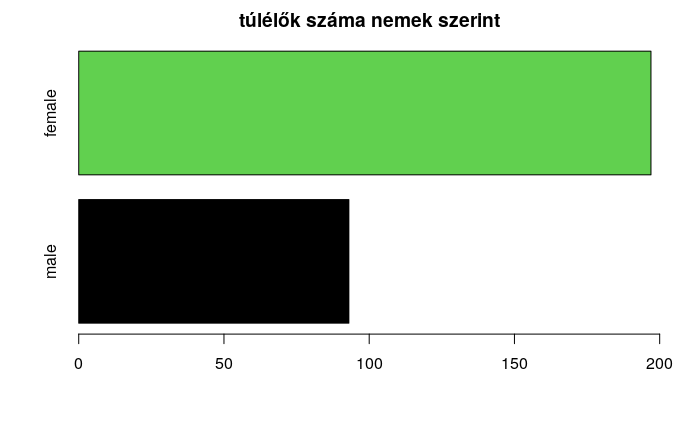

```r
survived_bar <- c(males,females)
names(survived_bar) <- c("male","female")
barplot(survived_bar,horiz = T,col = survived_bar/10,xlim=c(0,200),main= "túlélők száma nemek szerint")
```

Láthatjuk hogy több mint kétszerannyi nő élte túl, mint férfi.

#Nézzük meg ezt százalékos arányban is.

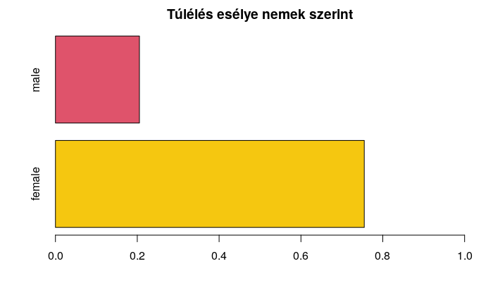

```r
survived <- train[train$Survived == 1,]
femalePct <- sum(survived$Sex == "female") / sum(train$Sex == "female")
malePct <- sum(survived$Sex == "male") / sum(train$Sex == "male")
allPct <- c(femalePct,malePct)
names(allPct) <- c("female","male")
barplot(allPct,col = allPct*10,horiz = T,xlim = c(0,1),main="Túlélés esélye nemek szerint")
```

Óriási különbséget tapasztalunk a két valószínűségben.

#Nézzuk meg az emberek korainak eloszlását:

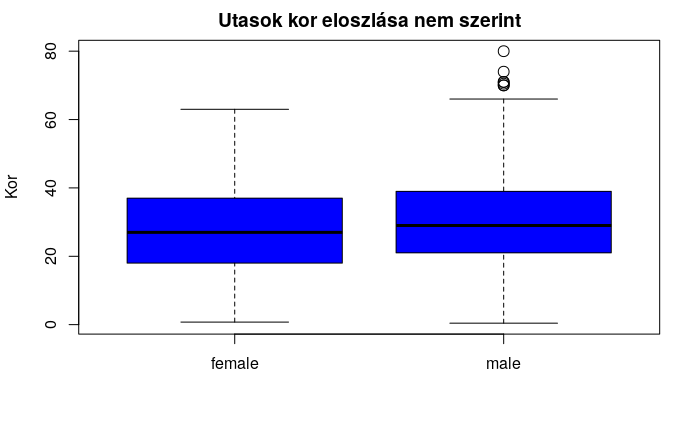

```r
plot(x = train$Sex, y = train$Age,
col ="blue", pch = 1, cex = 1.5,
main = "Utasok kor eloszlása nem szerint",
xlab = "",
ylab = "Kor"
)
```

Mint láthatjuk, javarészt fiatal felnőttek és középkorúak utaztak a hajón. Most nezzuk meg hogy ez hogy nez ki, ha csak a tuleloket vesszuk bele:

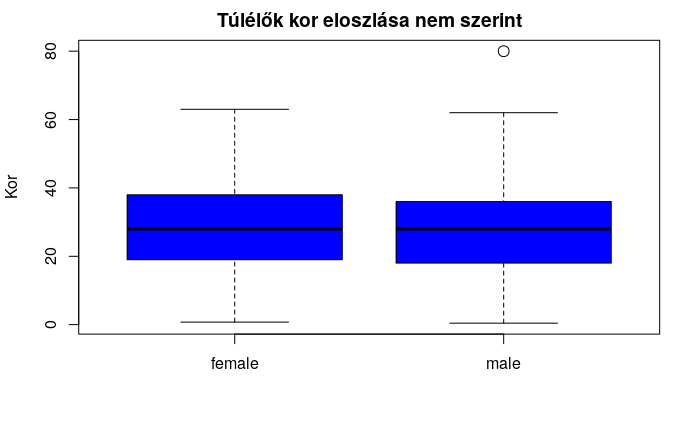

```r
plot(x = survived$Sex, y = survived$Age,
col ="blue", pch = 1, cex = 1.5,
main = "Túlélők kor eloszlása nem szerint",
xlab = "",
ylab = "Kor"
)
```

#Most nézzük meg százalékosan a túlélés esélyét, korokra lebontva.

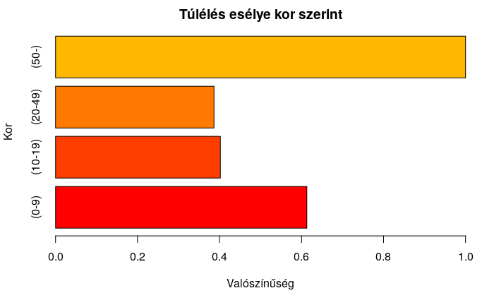

```r
kids <- sum(survived$Age < 10) / sum(train$Age < 10)
teenagers <- sum(survived$Age >= 10 & survived$Age < 20) / sum(train$Age >= 10 & train$Age < 20)
adults <- sum(survived$Age >= 20 & survived$Age < 50) / sum(train$Age >= 20 & train$Age < 50)
elders <- sum(survived$Age >= 50) / sum(survived$Age >= 50)
allAges <- c(kids,teenagers,adults,elders)
names(allAges) <- c("(0-9)","(10-19)","(20-49)","(50-)")
barplot(allAges,col = rainbow(25),horiz = T,xlim = c(0,1),main = "Túlélés esélye kor szerint",xlab="Valószínűség",ylab="Kor")
```

#Most nézzük meg hogy testvérek szerint hogyan oszlanak meg az utasok:

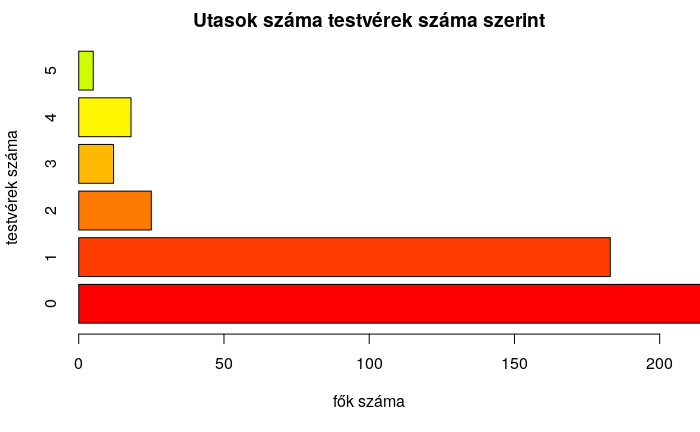

```r
sibsbTable <- table(train$SibSp)
barplot(sibsbTable,ylab="testvérek száma",xlab="fők száma",horiz = T,col= rainbow(25),xlim=c(0,200),main="Utasok száma testvérek száma szerint")
```

Ebből láthatjuk hogy a legtöbben vagy egyáltalán nem, vagy csak egy testvért hoztak az útra.

#Ezután azt is erdekes megfigyelni hogy hányan érkeztek gyermekkel vagy szülővel:

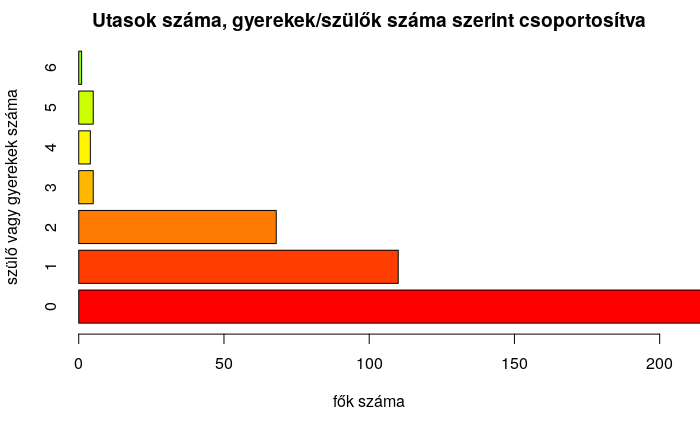

```r
parchTable <- table(train$Parch)
barplot(parchTable,ylab="szülő vagy gyerekek száma",xlab="fők száma",horiz = T,col= rainbow(25),xlim=c(0,200),main = "Utasok száma, gyerekek/szülők száma szerint csoportosítva")
```

Érdekes hogy van egy eset ahol 6 gyermek/szülő is jött az utassal, viszont nagyrészt itt is az utasok vagy egyáltalán nem vagy csak egy szülő/gyermek-et hoztak magukkal. Itt többen vannak olyanok is akik kettővel, viszont a többi nagyon elenyesző.

#Most nézzük meg hogy undulás szerint hogyan oszlanak meg az utasok:

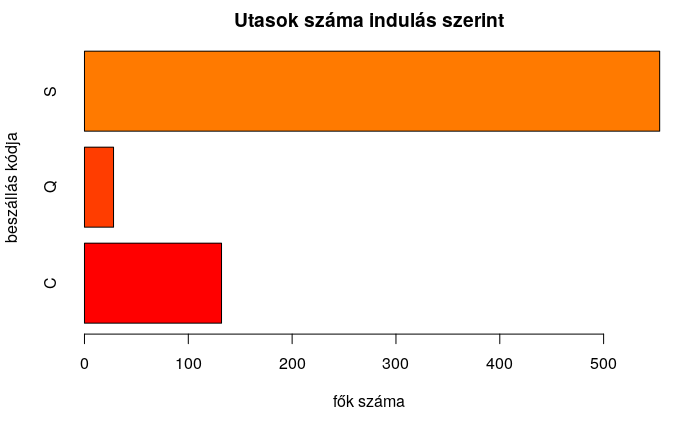

```r
embarkTable <- table(train$Embarked)
barplot(embarkTable,horiz = T,xlab="fők száma",ylab="beszállás kódja",col = rainbow(25),main="Utasok száma indulás szerint")
```

#Most ugyanezt a túlélőkre:

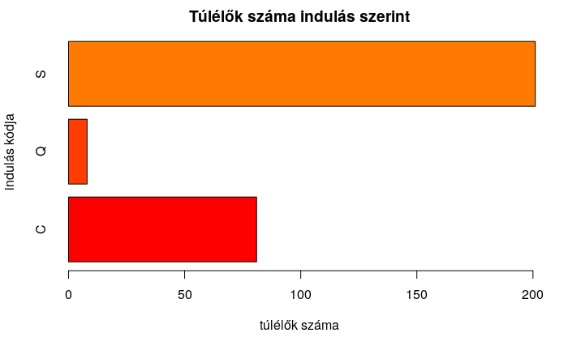

```r
survivedEmbarkTable <- table(survived$Embarked)
barplot(survivedEmbarkTable,col = rainbow(25),horiz = T,xlab="túlélők száma",ylab="indulás kódja",main="Túlélők száma indulás szerint")
```

#Most nézzük meg hogy az indulási kódok mennyire befolyásolták a túlélés esélyét

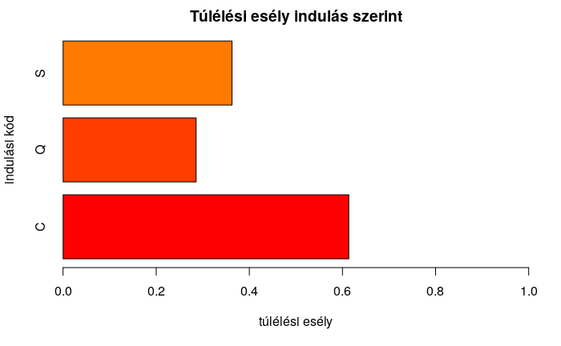

```r
cPct <- sum(survived$Embarked == "C") / sum(train$Embarked == "C")
qPct <- sum(survived$Embarked == "Q") / sum(train$Embarked == "Q")
sPct <- sum(survived$Embarked == "S") / sum(train$Embarked == "S")
allPct <- c(cPct,qPct,sPct)
names(allPct) <- c("C","Q","S")
barplot(allPct,col = rainbow(25),main="Túlélési esély indulás szerint",horiz = T,xlab = "túlélési esély",ylab = "indulási kód",xlim= c(0,1))
```

Így mostmár láthatjuk hogy a C indulási kóddal rendelkezők nagyobb eséllyel élték túl.

#Ezutan nezzunk meg egy kicsit erdekesebb osszefuggest is, megpedig hogy osztalyok szerint milyen eloszlasban eltek tul az utasok:

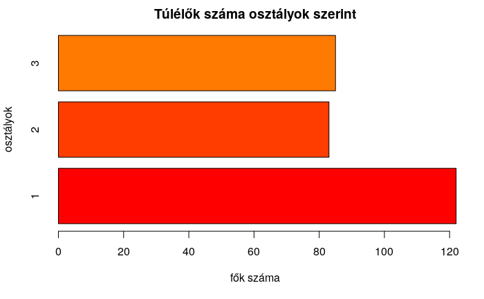

```r
pclassTable <- table(survived$Pclass)
barplot(pclassTable,xlab="fők száma", ylab="osztályok",col=rainbow(25),horiz = T,main = "Túlélők száma osztályok szerint")
```

Érdekes látni hogy első osztályon utazóként sokkal nagyobb eséllyel élték túl az emberek, és hogy a második és harmadik osztályon ugyanannyian vannak nagysagrendileg a túlélők.

#Ezutan azt is erdekes lenne megtekinteni hogy szazalekos aranyban hogy nez ki a tulelok aranya, osztalyok szerint:

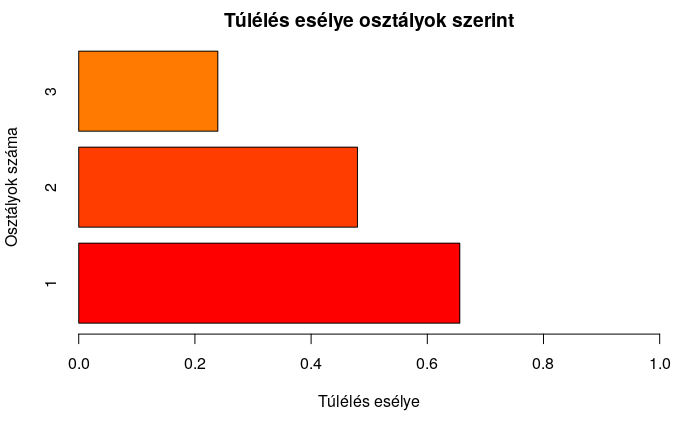

```r
c1pct <- (sum(survived$Pclass == 1) / sum(train$Pclass == 1))
c2pct <- (sum(survived$Pclass == 2) / sum(train$Pclass == 2))
c3pct <- (sum(survived$Pclass == 3) / sum(train$Pclass == 3))
allPct <- c(c1pct,c2pct,c3pct)
names(allPct) <- c(1,2,3)
barplot(allPct,xlim=c(0,1),horiz = T,col = rainbow(25),xlab = "Túlélés esélye",ylab = "Osztályok száma", main = "Túlélés esélye osztályok szerint")
```

Százalékosan nézve az arányokat viszont nagyon látszik, hogy minél alacsonyabb osztályon utazott az utas, annál kevesebb esélye volt túlélni a katasztrófát.

#Most vizsgáljuk meg az attribútumok közötti korrelációkat: -ehhez numerikus értékké kell alakítani amit tudunk, amit meg nem(Name,Embarked stb.) azt meg kihagyjuk.

```r
corTrain <- train
corTrain$PassengerId <- NULL
corTrain$Name <- NULL
corTrain$Embarked <- NULL
corTrain$Sex <- as.numeric(train$Sex)
corTrain$Pclass <- as.numeric(train$Pclass)
cor(corTrain)
```

```
            Survived      Pclass         Sex         Age       SibSp       Parch        Fare
Survived  1.00000000 -0.35965268 -0.53882559 -0.07722109 -0.01735836  0.09331701  0.26818862
Pclass   -0.35965268  1.00000000  0.15546030 -0.36922602  0.06724737  0.02568307 -0.55418247
Sex      -0.53882559  0.15546030  1.00000000  0.09325358 -0.10394968 -0.24697204 -0.18499425
Age      -0.07722109 -0.36922602  0.09325358  1.00000000 -0.30824676 -0.18911926  0.09606669
SibSp    -0.01735836  0.06724737 -0.10394968 -0.30824676  1.00000000  0.38381986  0.13832879
Parch     0.09331701  0.02568307 -0.24697204 -0.18911926  0.38381986  1.00000000  0.20511888
Fare      0.26818862 -0.55418247 -0.18499425  0.09606669  0.13832879  0.20511888  1.00000000
```

#Most készítsünk egy regressziós modellt, binomiális prediktorral:

```r
model <- glm(Survived ~ Age + Sex + Pclass + Embarked, data = train, family = binomial)
summary(model)
```

```
Call:
glm(formula = Survived ~ Age + Sex + Pclass + Embarked, family = binomial,
    data = train)

Deviance Residuals:
    Min       1Q   Median       3Q      Max
-2.6472  -0.6800  -0.3972   0.6349   2.4718

Coefficients:
             Estimate Std. Error z value Pr(>|z|)
(Intercept)  4.048317   0.430608   9.401  < 2e-16 ***
Age         -0.035906   0.007704  -4.661 3.15e-06 ***
Sexmale     -2.522729   0.209107 -12.064  < 2e-16 ***
Pclass2     -1.148294   0.290763  -3.949 7.84e-05 ***
Pclass3     -2.413335   0.291246  -8.286  < 2e-16 ***
EmbarkedQ   -0.824315   0.567901  -1.452   0.1466
EmbarkedS   -0.503245   0.266341  -1.889   0.0588 .
---
Signif. codes:  0 ‘***’ 0.001 ‘**’ 0.01 ‘*’ 0.05 ‘.’ 0.1 ‘ ’ 1

(Dispersion parameter for binomial family taken to be 1)

    Null deviance: 964.52  on 713  degrees of freedom
Residual deviance: 643.11  on 707  degrees of freedom
AIC: 657.11

Number of Fisher Scoring iterations: 5
```

#Ebből leolvashatjuk: -a nemeknél ha az utas férfi, akkor 2.52-vel romlik az esélye -a pclass-nál 1,14-el romlik az esély, ha valaki másod osztályon utazott, illetve 2,41-el, ha harmad osztályon

```r
exp(model$coefficients)
```

```
(Intercept)         Age     Sexmale     Pclass2     Pclass3   EmbarkedQ   EmbarkedS
57.30096397  0.96473119  0.08024037  0.31717747  0.08951629  0.43853520  0.60456593
```

#Most nézzük meg hogy milyen eredményt kapunk a tesztadatokra

```r
pred <- predict(model,newdata = test)
test$pred <- pred > 1
test$pred <- factor(test$pred,c(FALSE,TRUE),c('0','1'))
sum(test$pred == "1") / length(test$PassengerId)
```

```
[1] 0.2477341
```

A predikció szerint a tesztadatok utasainak csupán a 24,7%-a élte túl.

#Nézzük meg, hogy milyen arányban sikerült predikálni a túlélést:

```r
accuracy(test$Survived,test$pred)
```

```
[1] 0.8519637
```

Az accuracy függvény szerint, 85%-ban sikerült jól predikálni a túléléseket.

#Modell kiértékelés

```r
cor(train$Survived,model$fitted.values)
```

```
[1] 0.6403839
```

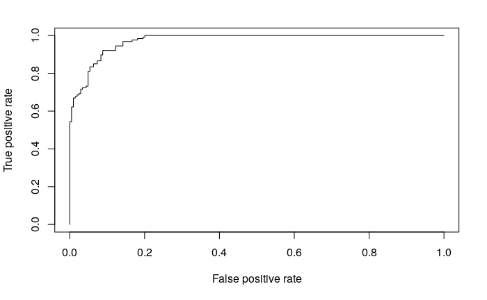

```r
pr <- prediction(pred,test$Survived)
perf <- performance(pr,measure = "tpr", x.measure = "fpr")
plot(perf)
```

```r
auc(test$Survived,test$pred)
```

```
[1] 0.8100587
```

Az AUC elég magas, 81%, és a ROC görbe is jól mutatja, hogy kevés hibával dolgozott a modell.

#Most alkalmazzuk rajta a randomForest klasszifikációs modellt:

```r
modelRF <- randomForest(factor(Survived) ~ Pclass + Fare + Embarked + Sex, data=train, importance=TRUE)
modelRF
```

```
Call:
 randomForest(formula = factor(Survived) ~ Pclass + Fare + Embarked +      Sex, data = train, importance = TRUE)
               Type of random forest: classification
                     Number of trees: 500
No. of variables tried at each split: 2

        OOB estimate of  error rate: 19.89%
Confusion matrix:
    0   1 class.error
0 402  22  0.05188679
1 120 170  0.41379310
```

#Most elemezzük a modellt:

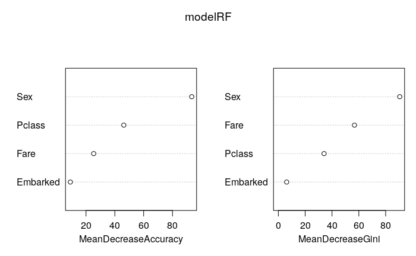

```r
varImpPlot(modelRF)
```

```r
importance(modelRF)
```

```
                0         1 MeanDecreaseAccuracy MeanDecreaseGini
Pclass   23.67222 37.645862            46.226310        34.089692
Fare     20.25929 12.240221            25.331308        56.743253
Embarked 10.77754 -1.578283             9.141445         6.195191
Sex      63.19627 92.337569            93.351957        90.491689
```

Ezekből láthatjuk hogy a különböző attribútumok milyen fontosságúak.

#miután kész a modell, jöhet a predikció:

```r
test$predRF <- predict(modelRF,newdata = test)
sum(test$predRF == "1") / length(test$PassengerId)
```

```
[1] 0.3021148
```

Ezuttal már az utasok 30%-a élte túl, ebből arra következtethetünk, hogy vagy jobb lesz a teljesítménye ennek a modellnek, vagy pedig sok false positive eredmény lett, tehát olyan utas, aki nem élte túl, túléltnek osztályozva. #az accuracy-vel ezt leellenőrizhetjük:

```r
accuracy(test$Survived,test$predRF)
```

```
[1] 0.918429
```

Köszönöm hogy végigolvastad ezt a notebookot. Forrás: -a dataset itt található meg: https://www.kaggle.com/c/titanic -a randomForest alkalmazását innen tanultam: https://www.kaggle.com/lashkare/simple-yet-effective-titanic-solution#SPLITTING-DATA-INTO-TRAINING-AND-TEST-SET